# Reproducible Research: Peer Assessment 1

##### Loading and preprocessing the data

- Load the data

```r
#Loading and preprocessing the data ***********************************************************
#--d_r, raw data
d_r <- read.table('activity.csv',
                 header=T,
                 sep=',',
                 stringsAsFactors=F)
```

- Process/transform the data into a format suitable for analysis
  - Only include complete rows where there are no na’s.
  - Convert time interval to hh:mm representation.

```r
#--number of complete rows without an 'na'
#----d_c, data clean
d_c = d_r[which( complete.cases(d_r) ), ]
#--hh:mm format for interval
d_c$interval = sprintf("%04d", d_c$interval)
d_c$interval = paste( substr(d_c$interval, 1,2), ':', substr(d_c$interval, 3,4), sep='' )
str(d_c)
```

```
## 'data.frame':    15264 obs. of  3 variables:
##  $ steps   : int  0 0 0 0 0 0 0 0 0 0 ...
##  $ date    : chr  "2012-10-02" "2012-10-02" "2012-10-02" "2012-10-02" ...
##  $ interval: chr  "00:00" "00:05" "00:10" "00:15" ...
```

##### What is mean total number of steps taken per day?

- Missing values are ignored in the dataset for this section.
- Histogram of the total number of steps taken each day.

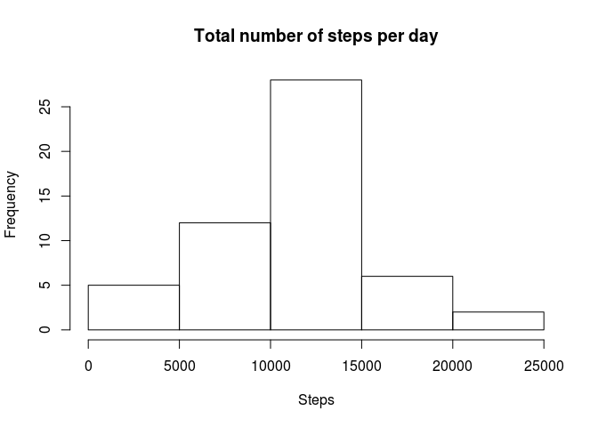

```r
#--grouped by date, mean number of steps per day
g_date = aggregate(d_c$steps, list(date=d_c$date), sum)
names(g_date)[2] = 'steps'
hist(g_date$steps, main='Total number of steps per day', xlab='Steps')
```

- Mean total number of steps per day.

```r
#--mean number of steps per day
paste('Mean number of steps per day:', mean(g_date$steps))
```

```
## [1] "Mean number of steps per day: 10766.1886792453"
```

- Median total number of steps per day.

```r
#--median number of steps per day
paste('Median number of steps per day:', median(g_date$steps))
```

```
## [1] "Median number of steps per day: 10765"
```

We notice the data is very symmetrical and the mean and median are almost identical.

##### What is the average daily activity pattern?

- Time series plot of the 5-minute interval (x-axis) and the average number of steps taken, averaged across all days (y-axis). For some reason I just cannot get the graph to be a line plot, even though type=‘l’.

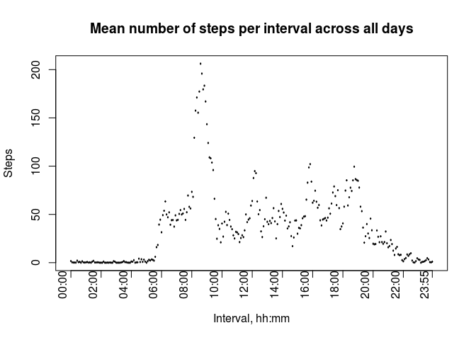

```r
#What is the average daily activity pattern? *************************************************
#--interval on average over all days with max steps
#----grouped by interval
ms = aggregate(d_c$steps, list(interval = d_c$interval), mean)
names(ms)[2] = 'steps'
plot(x=as.factor(ms$interval),
     y=ms$steps,
     type='l', lty=1, lwd=1,
     xaxt='n',
     main='Mean number of steps per interval across all days',
     xlab='Interval, hh:mm',
     ylab='Steps'
     )
axis(1,
     las=1,
     at=c(1,25,49,73,97,121,145,169,193,217,241,265,288),
     labels = F
     )
text(c(1,25,49,73,97,121,145,169,193,217,241,265,288),
     labels=c('00:00','02:00','04:00','06:00','08:00','10:00','12:00',
         '14:00','16:00','18:00','20:00','22:00', '23:55'),
     par("usr")[3] - 0.2,
     pos=2,
     xpd=T,
     srt=90
)
```

- Which 5-minute interval, on average across all the days in the dataset, contains the maximum number of steps?

```r
#--max steps interval
paste('Time interval on average for maximum number of steps:'
       ,ms[which(ms$steps==max(ms$steps)), ])
```

```
## [1] "Time interval on average for maximum number of steps: 08:35"
## [2] "Time interval on average for maximum number of steps: 206.169811320755"
```

##### Imputing missing values

- Calculate and report the total number of missing values in the dataset (i.e. the total number of rows with NAs)

```r
#--number of rows with missing values
paste('Number of rows with missing data:', nrow(d_r) - nrow(d_c))
```

```
## [1] "Number of rows with missing data: 2304"
```

- Devise a strategy for filling in all of the missing values in the dataset. I have used median value across all days per interval as an imputed value.

```r
#--missing values will be replaced with median over all days
#--for that interval
md = aggregate(d_c$steps, list(interval = d_c$interval), median)
names(md)[2] = 'steps'
md = cbind(md, int_interval = as.integer( paste( substr(md$interval,1,2), substr(md$interval,4,5), sep='' ) ))
#--data transformed, d_t
d_t = d_r
for (n in 1:nrow(d_t)) {
  if (sum(is.na(d_t[n,])) > 0) {
    #--row contain an na
    #--replace with median steps, md$steps
    d_t[n,]$steps = md[which(md$int_interval==d_t[n,]$interval), 2]
  }
}
#--d_t, new dataset that is same as original dataset (d_r)
#--but with the missing data filled in
```

- Make a histogram of the total number of steps taken each day. Calculation is based on NA’s replaced with imputed values from the raw data.

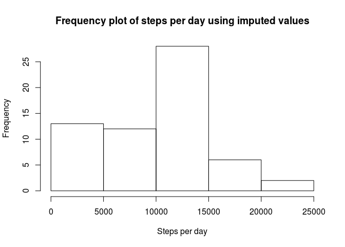

```r
#--number of steps per day
#----grouped by date
d_t_date = aggregate(d_t$steps, list(date=d_t$date), sum)
names(d_t_date)[2] = 'steps'
hist(d_t_date$steps,
     main='Frequency plot of steps per day using imputed values',
     xlab='Steps per day'
     )
```

- Calculate and report the mean and median total number of steps with the imputed data.
- Mean with imputed data

```r
#--mean number of steps per day with imputed data
paste('Mean number of steps per day with imputed data:', mean(d_t_date$steps))
```

```
## [1] "Mean number of steps per day with imputed data: 9503.86885245902"
```

- median with imputed data

```r
#--median number of steps per day, with imputed data
paste('Median number of steps per day with imputed data:', median(d_t_date$steps))
```

```
## [1] "Median number of steps per day with imputed data: 10395"
```

- Difference in mean, median between raw data with dropped NA rows, and data with imputed values for NA rows.

```r
#--difference in means, medians
#----diff in mean
paste('Diff in means:', mean(d_t_date$steps) - mean(g_date$steps))
```

```
## [1] "Diff in means: -1262.31982678627"
```

```r
#----diff in median
paste('Diff in medians:', median(d_t_date$steps) - median(g_date$steps))
```

```
## [1] "Diff in medians: -370"
```

We see, by including imputed data, the mean is reduced by around 10 percent. The medians are still very similar.

##### Are there differences in activity patterns between weekdays and weekends?

- Create a new factor variable in the dataset with two levels – “weekday” and “weekend” indicating whether a given date is a weekday or weekend day.

```r
#Are there differences in activity patterns between weekdays and weekends?*****************
#--create weekday/ weekend 2-factor vector
v = d_t$date
v[] = 'weekday'
v[which( substr( weekdays( as.Date( d_t$date ) ), 1, 1 ) == 'S' )] = 'weekend'
d_t = cbind(d_t, span=as.factor(v))
#--hh:mm format for interval
d_t$interval = sprintf("%04d", d_t$interval)
d_t$interval = paste( substr(d_t$interval, 1,2), ':', substr(d_t$interval, 3,4), sep='' )
str(d_t)
```

```
## 'data.frame':    17568 obs. of  4 variables:
##  $ steps   : int  0 0 0 0 0 0 0 0 0 0 ...
##  $ date    : chr  "2012-10-01" "2012-10-01" "2012-10-01" "2012-10-01" ...
##  $ interval: chr  "00:00" "00:05" "00:10" "00:15" ...
##  $ span    : Factor w/ 2 levels "weekday","weekend": 1 1 1 1 1 1 1 1 1 1 ...
```

- Make a panel plot containing a time series plot (i.e. type = “l”) of the 5-minute interval (x-axis) and the average number of steps taken, averaged across all weekday days or weekend days (y-axis).

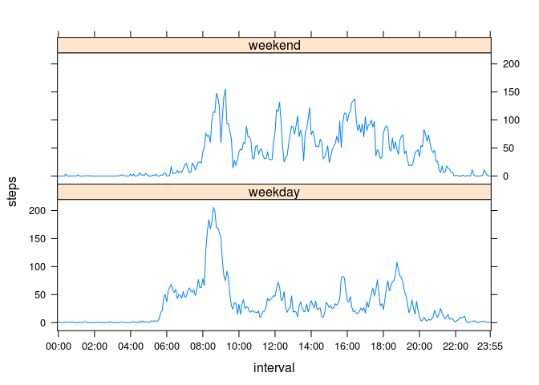

```r
#--grouped by 2-factor (weeked or weekday) + interval
#--mean number of steps per day per period, with imputed data
d1 = aggregate(d_t$steps, list(span=d_t$span, interval=d_t$interval), mean)
names(d1)[3] = 'steps'

#--lattice plot for 2-factor weekend and weekday
library(lattice)
xyplot(d1$steps~as.factor(d1$interval) | d1$span,
       d1,
       layout=c(1,2),
       type='l',
       xlab='interval',
       ylab='steps',
       scales=list(x=list(at=c(1,25,49,73,97,121,145,169,193,217,241,265,288),
                          labels=c('00:00','02:00','04:00','06:00','08:00','10:00','12:00',
                                   '14:00','16:00','18:00','20:00','22:00', '23:55')
         ))
       )
```

From the lattice plot one can clearly see peak activity in the early morning on weekdays is higher than the weekend.

Weekend data shows somewhat higher usage during the day, which is hardly suprising as people are at work during the working day.